# Cereal Stats

## Cereal Stats

Using the [80 Cereals Dataset](https://www.kaggle.com/crawford/80-cereals) on Kaggle run various visualizations to learn data visualization and reading and understanding data

```python
import pandas as pd
import numpy as np
import seaborn as sns
import matplotlib.pyplot as plt
from scipy import stats
%matplotlib inline
```

### Preparing data

Before we can plot and analyze this data we need to bring all this raw data into a format we can manipulate in Python easier

The most popular way of doing this is to use a Pandas Dataframe

```python
cereal_frame = pd.read_csv("./cereal.csv")

cereal_frame.head()
```

|  | name | mfr | type | calories | protein | fat | sodium | fiber | carbo | sugars | potass | vitamins | shelf | weight | cups | rating |
| --- | --- | --- | --- | --- | --- | --- | --- | --- | --- | --- | --- | --- | --- | --- | --- | --- |
| 0 | 100% Bran | N | C | 70 | 4 | 1 | 130 | 10.0 | 5.0 | 6 | 280 | 25 | 3 | 1.0 | 0.33 | 68.402973 |
| 1 | 100% Natural Bran | Q | C | 120 | 3 | 5 | 15 | 2.0 | 8.0 | 8 | 135 | 0 | 3 | 1.0 | 1.00 | 33.983679 |
| 2 | All-Bran | K | C | 70 | 4 | 1 | 260 | 9.0 | 7.0 | 5 | 320 | 25 | 3 | 1.0 | 0.33 | 59.425505 |
| 3 | All-Bran with Extra Fiber | K | C | 50 | 4 | 0 | 140 | 14.0 | 8.0 | 0 | 330 | 25 | 3 | 1.0 | 0.50 | 93.704912 |
| 4 | Almond Delight | R | C | 110 | 2 | 2 | 200 | 1.0 | 14.0 | 8 | -1 | 25 | 3 | 1.0 | 0.75 | 34.384843 |

Now that the data is loaded up we need to check for any rows with missing values. If there are any missing values we fill those missing values with either the mean, median or mode of the other values in that column

```python
## Count missing values in each column
cereal_frame.isna().sum()
```

```
name        0
mfr         0
type        0
calories    0
protein     0
fat         0
sodium      0
fiber       0
carbo       0
sugars      0
potass      0
vitamins    0
shelf       0
weight      0
cups        0
rating      0
dtype: int64
```

Luckily we do not have any missing values so every row has a value for us to work with. Now lets start graphing this data and visualizing relationships between each feature.

*A feature is column in our dataframe, i.e name, mfr, type etc.*

First lets see how the amount of sugar in the cereal relates to the number of calories

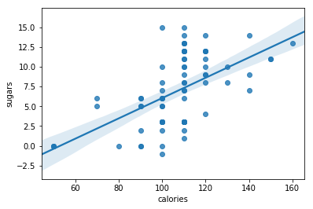

```python
sns.regplot(cereal_frame['calories'], cereal_frame['sugars'])
```

We can see as predicted that as the amount of sugar increases then the number of calories increases as well

Next lets try a few more

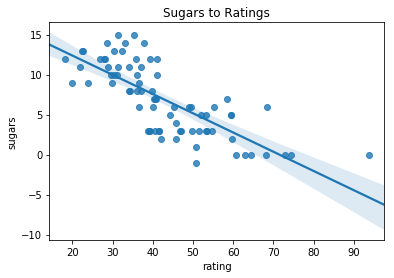

```python
rating_to_sugars = sns.regplot(cereal_frame['rating'], cereal_frame['sugars'])
rating_to_sugars.set_title('Sugars to Ratings')
rating_to_sugars
```

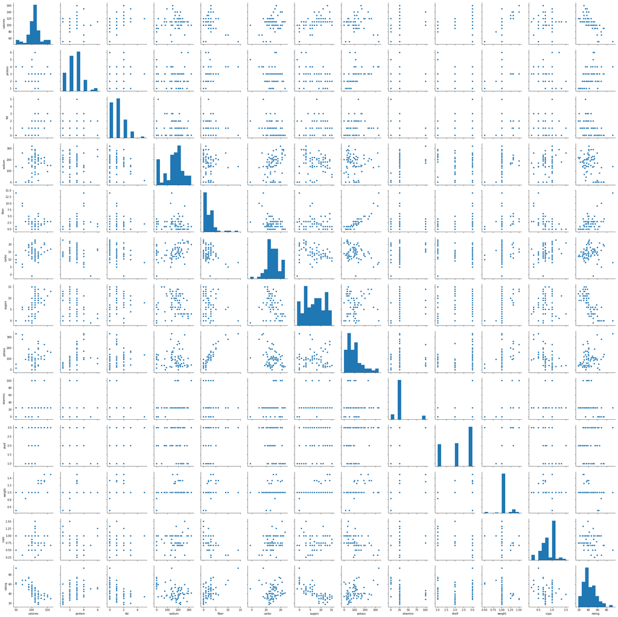

```python
sns.pairplot(cereal_frame)
```

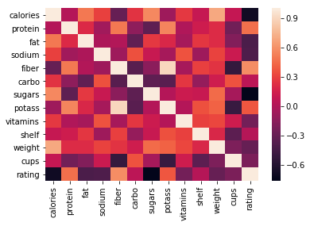

```python
cor = cereal_frame.corr()
sns.heatmap(cor, xticklabels=cor.columns, yticklabels=cor.columns)
```

The above two plots show us the corelation between each feature in the cereal dataframe

## How to Interpret the Graphs

### Pairwise Plot

The pairwise plot is a scatter plot plotted against each feature. Scatter plots tell us the relationship between two variables. If you cannot see any positive or negative relationship between two feature then the two features are not related to each other.

Some things we can notice are

- Fiber and potassium are positively correlated
- As sugar increases the rating goes down, suggesting that the survey audience might be adults
- Sodium and carbohydrates are also positively correlated

### Correlation Matrix

A correlation gives us a much more precise measure as to how related (positive/negative) two feature are to each other.

The Pearson Correaltion value can be interpretted as follows:

> Exactly –1. A perfect downhill (negative) linear relationship

> –0.70. A strong downhill (negative) linear relationship

> –0.50. A moderate downhill (negative) relationship

> +0.30. A weak uphill (positive) linear relationship

> +0.50. A moderate uphill (positive) relationship

> +0.70. A strong uphill (positive) linear relationship

> Exactly +1. A perfect uphill (positive) linear relationship

## Understanding the data distribution

Another important part of understanding data is to check the distribution of the data. We would like the data to all the as close to standard normal as possible.

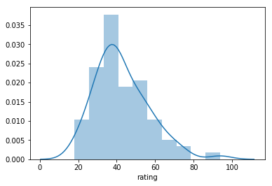

```python
sns.distplot(cereal_frame['rating'])
plt.show()
```

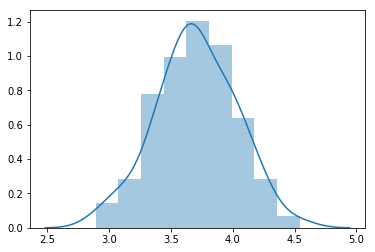

```python
from scipy.stats import boxcox

sns.distplot(boxcox(cereal_frame['rating'], lmbda=0.0))
plt.show()
```

Now we can see that the distrobution is normal. Let's try this with other features in the dataset.

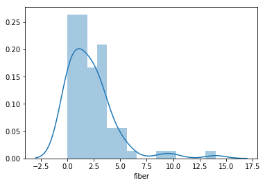

```python
sns.distplot(cereal_frame['fiber'])
```

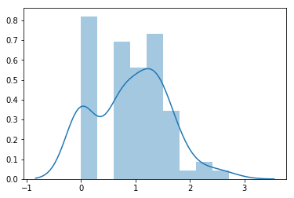

```python
offset = abs(cereal_frame['fiber'].min())
cereal_frame['fiber_bxcx'] = cereal_frame['fiber'].apply(lambda x: x + offset + 1)
sns.distplot(boxcox(cereal_frame['fiber_bxcx'], lmbda=0.0))
```

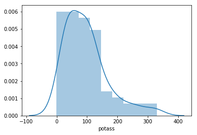

```python
sns.distplot(cereal_frame['potass'])
```

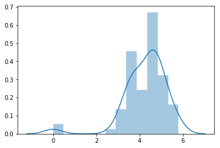

```python
offset = abs(cereal_frame['potass'].min())
cereal_frame['potass_bxcx'] = cereal_frame['potass'].apply(lambda x: x + offset + 1)
sns.distplot(boxcox(cereal_frame['potass_bxcx'], lmbda=0.0))
```